# spatialkit: Tessellations, Spatial Cross-Validation and Models

Justin Chase

2026-08-26

## Overview

This vignette generates **synthetic spatial data** over North Carolina and walks through the `spatialkit` workflow end to end:

1. Build four tessellation types (Voronoi, hex, square, Delaunay)
2. Assign points to cells and aggregate with `summarize_by_cell()`
3. Draw choropleths of the cell-level mean response
4. Estimate the autocorrelation range and build spatial CV folds
5. Fit a model, and score it under **blocked** versus **random** folds
6. Predict onto a surface and mark where that surface is extrapolation

Everything is self-contained — the boundary comes from the `nc.shp` demo shapefile bundled with `sf`, so no external files are needed.

Optional backends are checked at the top and every section that needs one is guarded, so this document renders with whatever you happen to have installed:

```
##        package available                          used_for
## 1      ggplot2      TRUE                         all plots
## 2     geometry      TRUE       true Delaunay triangulation
## 3       ranger      TRUE             random forest backend
## 4        gstat      TRUE variogram / autocorrelation range
## 5 GWmodel + sp     FALSE                       GWR backend
```

## 1. Packages and boundary

```r
library(spatialkit)
library(sf)
library(dplyr)
library(ggplot2)

set.seed(42)
```

```r
nc_counties <- st_read(system.file("shape/nc.shp", package = "sf"), quiet = TRUE)
nc_boundary <- nc_counties |>
  st_union() |>
  st_transform(2264) |>
  st_as_sf()
```

## 2. Synthetic observations

300 points inside the state boundary with two predictors and a spatially varying response:

- `elevation` — gradient increasing west to east, plus noise
- `pop_density` — decays with distance from two fake “cities”
- `y` — driven by the two predictors **plus a spatial field neither of them explains**. That last term is deliberate: it is the unmodelled spatial structure that makes random cross-validation optimistic, and it is what section 5 measures.

```r
n_points <- 300

pts_raw    <- st_sample(nc_boundary, size = n_points, type = "random")
pts_coords <- st_coordinates(pts_raw)
x_coords   <- pts_coords[, 1]
y_coords   <- pts_coords[, 2]

elevation <- scale(x_coords)[, 1] * 500 + rnorm(n_points, 3000, 400)

city1 <- c(1530000, 550000)   # Charlotte-ish in EPSG:2264
city2 <- c(2150000, 750000)   # Raleigh-ish
dist_to_city <- pmin(
  sqrt((x_coords - city1[1])^2 + (y_coords - city1[2])^2),
  sqrt((x_coords - city2[1])^2 + (y_coords - city2[2])^2)
)
pop_density <- pmax(exp(-dist_to_city / 400000) * 5000 + rnorm(n_points, 200, 100), 10)

spatial_field <- 20 * sin(x_coords / 250000) * cos(y_coords / 250000)

y_response <- 50 +
  0.01  * elevation +
  0.005 * pop_density +
  spatial_field +
  rnorm(n_points, 0, 5)

points_sf <- st_sf(
  y           = y_response,
  elevation   = elevation,
  pop_density = pop_density,
  geometry    = pts_raw
)
```

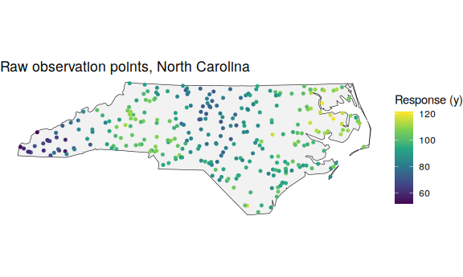

```r
ggplot() +
  geom_sf(data = nc_boundary, fill = "grey95", colour = "black") +
  geom_sf(data = points_sf, aes(colour = y), size = 1.1) +
  scale_colour_viridis_c(name = "Response (y)") +
  theme_void() +
  ggtitle("Raw observation points, North Carolina")
```

## 3. Four tessellations

### 3a. Voronoi from ~40 k-means seeds

Voronoi cells are built around *seed* points, not the observations themselves. Seeding one cell per observation would give 300 cells each containing a single point — a nearest-neighbour interpolation rather than an aggregation, with no within-cell variation to compute a standard error from. `get_voronoi_seeds()` clusters the observations first, so cell size follows sampling density.

```r
seeds <- get_voronoi_seeds(
  boundary      = nc_boundary,
  sample_points = points_sf,
  method        = "kmeans",
  n             = 40
)

tess_voronoi <- build_tessellation(
  seeds, boundary = nc_boundary,
  method = "voronoi", clip = TRUE, quiet = TRUE
)
```

### 3b and 3c. Hex and square grids (~50 cells)

```r
tess_hex <- build_tessellation(
  points_sf, boundary = nc_boundary,
  method = "hex", approx_n_cells = 50, clip = TRUE, quiet = TRUE
)

tess_square <- build_tessellation(
  points_sf, boundary = nc_boundary,
  method = "square", approx_n_cells = 50, clip = TRUE, quiet = TRUE
)
```

All four methods return cells carrying a `cell_id` column; the grid methods keep `poly_id` alongside it, holding the same values.

```r
names(tess_hex$cells)
```

```
## [1] "poly_id"  "geometry" "cell_id"
```

### 3d. Delaunay triangles

`method = "triangles"` uses `geometry::delaunayn()` when `geometry` is installed. Without it, it does **not** error — it falls back to `sf::st_triangulate()` (GEOS) on the point set and logs a warning. That is still the Delaunay triangulation of the input points; only the resolution of degenerate configurations can differ. Because the two paths are not identical, this section is guarded on `geometry` rather than on the call succeeding:

```r
tess_tri <- build_tessellation(
  points_sf, boundary = nc_boundary,
  method = "triangles", clip = TRUE, quiet = TRUE
)
nrow(tess_tri$cells)
```

```
## [1] 586
```

```r
cat(sprintf(
  "Voronoi: %d | Hex: %d | Square: %d | Triangles: %s\n",
  nrow(tess_voronoi$cells),
  nrow(tess_hex$cells),
  nrow(tess_square$cells),
  if (has_geom) nrow(tess_tri$cells) else "skipped (install 'geometry')"
))
```

```
## Voronoi: 40 | Hex: 49 | Square: 45 | Triangles: 586
```

## 4. Cell-level aggregation with `summarize_by_cell()`

`assign_features_to_polygons()` joins points to cells; `summarize_by_cell()` does the aggregation — means, standard deviations and standard errors for the response and every predictor, plus `n` and `cell_weight`. There is no need to write the `group_by()`/`summarise()` by hand, and doing so loses the design-effect machinery below.

```r
assigned <- assign_features_to_polygons(points_sf, tess_voronoi$cells,
                                        polygon_id_col = "cell_id")

cell_stats <- summarize_by_cell(
  assigned,
  response_var   = "y",
  predictor_vars = c("elevation", "pop_density"),
  id_col         = "cell_id"
)

head(as.data.frame(cell_stats)[, c("cell_id", "n", "resp_mean_y",
                                   "..sd_resp_y", "..se_resp_y")])
```

```
##   cell_id n resp_mean_y ..sd_resp_y ..se_resp_y
## 1       1 6    62.89141    7.074136    2.888004
## 2       2 7    63.36230    7.516155    2.840840
## 3       3 5    67.11282    8.521317    3.810849
## 4       4 5    70.34951   12.427812    5.557886
## 5       5 5    79.61205    5.327447    2.382507
## 6       6 4    84.14516    7.886035    3.943018
```

The `..se_*` columns are **IID** standard errors at the default `deff = 1`, which is anticonservative when points inside a cell are spatially correlated. `deff = "kish"` applies Kish’s design-effect correction from an estimated intra-class correlation, and `attr(., "deff_applied")` records what was used:

```r
cell_kish <- summarize_by_cell(
  assigned,
  response_var   = "y",
  predictor_vars = c("elevation", "pop_density"),
  id_col         = "cell_id",
  deff           = "kish"
)

deff <- attr(cell_kish, "deff_applied")
cat(sprintf("method = %s | ICC(response) = %.3f | median design effect = %.2f\n",
            deff$method, deff$icc_resp, stats::median(deff$deff, na.rm = TRUE)))
```

```
## method = kish | ICC(response) = 0.742 | median design effect = 5.45
```

```r
# Inflation of the response standard error, cell by cell.
summary(cell_kish$`..se_resp_y` / cell_stats$`..se_resp_y`)
```

```
##    Min. 1st Qu.  Median    Mean 3rd Qu.    Max.
##   1.796   2.170   2.335   2.391   2.633   3.147
```

### Choropleths

```r
#' Assign points to cells, summarise, and draw a choropleth.
make_choropleth <- function(tess, boundary, points, title = NULL) {
  cells    <- tess$cells
  assigned <- assign_features_to_polygons(points, cells, polygon_id_col = "cell_id")

  stats_df <- summarize_by_cell(assigned, response_var = "y",
                                id_col = "cell_id")
  cells    <- left_join(cells, as.data.frame(stats_df)[, c("cell_id", "resp_mean_y")],
                        by = "cell_id")

  plot_tessellation_map(
    tessellation_sf = cells,
    boundary        = boundary,
    fill_col        = "resp_mean_y",
    palette         = "viridis",
    tile_alpha      = 0.9,
    outline_col     = "white",
    outline_size    = 0.3,
    boundary_col    = "grey20",
    boundary_size   = 0.8,
    legend_title    = "Mean y",
    title           = title,
    subtitle        = sprintf("%d cells | %d observations",
                              nrow(cells), nrow(points))
  )
}
```

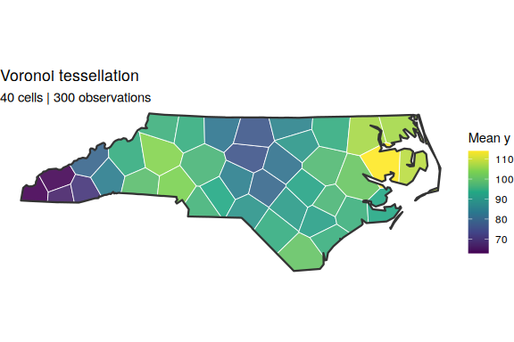

Voronoi choropleth

```r
make_choropleth(tess_voronoi, nc_boundary, points_sf, "Voronoi tessellation")
```

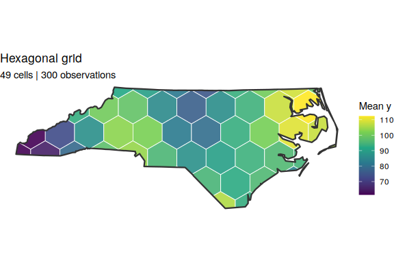

Hex grid choropleth

```r
make_choropleth(tess_hex, nc_boundary, points_sf, "Hexagonal grid")
```

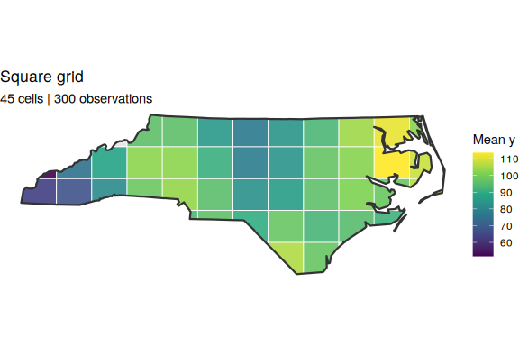

Square grid choropleth

```r
make_choropleth(tess_square, nc_boundary, points_sf, "Square grid")
```

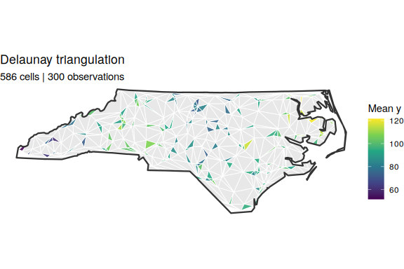

Delaunay choropleth

```r
make_choropleth(tess_tri, nc_boundary, points_sf, "Delaunay triangulation")
```

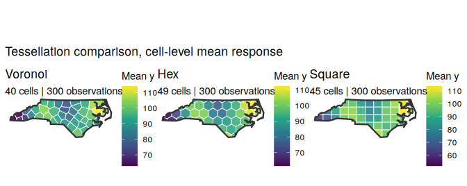

All three at a glance

```r
library(patchwork)

(make_choropleth(tess_voronoi, nc_boundary, points_sf, "Voronoi") |
 make_choropleth(tess_hex,     nc_boundary, points_sf, "Hex") |
 make_choropleth(tess_square,  nc_boundary, points_sf, "Square")) +
  plot_annotation(title = "Tessellation comparison, cell-level mean response")
```

## 5. Spatial cross-validation

This is the part the rest of the package exists to support.

### 5a. How far does correlation reach?

`estimate_sac_range()` fits directional variograms and returns the effective range in CRS units — here, US survey feet. It returns `NA` (still classed `sac_range`, so it prints as a bare `NA`) when the empirical variogram never reaches a sill, because an unidentified range must not be used to size blocks.

```r
sac <- estimate_sac_range(points_sf, response_var = "y",
                          predictor_vars = c("elevation", "pop_density"))
sac
```

```
## NA
```

```r
if (is.na(sac)) {
  cat("no identified range:", attr(sac, "rejected_reason"), "\n")
} else {
  cat(sprintf("range = %.0f ft; anisotropy ratio %.2f\n",
              as.numeric(sac), attr(sac, "anisotropy")))
}
```

```
## no identified range: fitted range exceeds the largest lag fitted
```

The fit is attached either way, so `plot(fit, type = "variogram")` on a fitted model can draw the curve and let you judge it rather than trust it. A rejected range must not be handed to `make_folds(auto_range = TRUE)`, which is why it comes back `NA` rather than as a long range.

### 5b. Two fold schemes on the same data

```r
folds_random  <- make_folds(points_sf, k = 5, method = "random_kfold", seed = 42)
folds_blocked <- make_folds(points_sf, k = 5, method = "block_kfold",  seed = 42)

c(random = folds_random$k, blocked = folds_blocked$k)
```

```
##  random blocked
##       5       5
```

`plot_folds()` is the fastest way to see whether the blocks actually separate the data or are smaller than the autocorrelation range and therefore leaking:

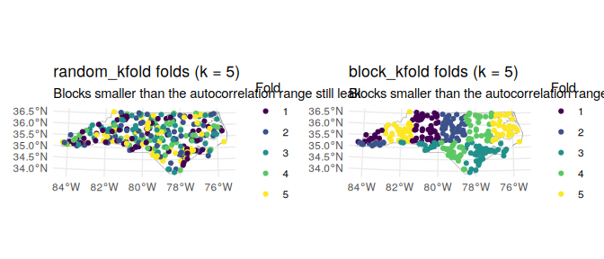

```r
library(patchwork)
plot_folds(folds_random,  points_sf, boundary = nc_boundary) +
  plot_folds(folds_blocked, points_sf, boundary = nc_boundary)
```

### 5c. The number the fold scheme changes

`fit_rf_model()` and `cv_rf()` need `ranger`. `include_coords = TRUE` hands the forest the coordinates, which lets it memorise the training surface — the failure mode the default (`FALSE`) exists to prevent, and the one random folds cannot see. Scoring the same model on both fold schemes shows the size of the gap:

```r
rf_args <- list(include_coords = TRUE, num_trees = 300, seed = 1)

cv_random  <- do.call(cv_rf, c(list(points_sf, "y", c("elevation", "pop_density"),
                                    folds = folds_random),  rf_args))
cv_blocked <- do.call(cv_rf, c(list(points_sf, "y", c("elevation", "pop_density"),
                                    folds = folds_blocked), rf_args))

data.frame(
  folds = c("random_kfold", "block_kfold"),
  R2    = c(cv_random$overall$R2,   cv_blocked$overall$R2),
  RMSE  = c(cv_random$overall$RMSE, cv_blocked$overall$RMSE)
)
```

```
##          folds        R2     RMSE
## 1 random_kfold 0.7946246 6.088389
## 2  block_kfold 0.6192885 9.140124
```

Random folds report R<sup>2</sup> = 0.795; blocked folds report 0.619 on the same fitted model — a drop of 22% of the reported skill.

The blocked estimate is the one to report. The random one describes interpolation between points you already have, which is not the task.

## 6. Fitting a model

```r
rf_fit <- fit_rf_model(points_sf, response_var = "y",
                       predictor_vars = c("elevation", "pop_density"))
rf_fit
```

```
## <Random Forest (ranger)> spatial model fit
##   Formula : y ~ elevation + pop_density
##   n       : 300
##   Trees   : 500 (mtry = 1, min node = 5)
##   Coords as predictors: no
##   OOB RMSE: 9.7284   OOB R²: 0.4733
##   Importance (permutation): elevation=105.4, pop_density=83.25
##
##   OOB is a random hold-out and is optimistic under spatial
##   autocorrelation; use cv_rf() for a spatial estimate.
```

Note that `summary()` on an `rf_fit` reports **out-of-bag** metrics, not in-sample ones — `fitted.rf_fit()` returns out-of-bag predictions, and the printout says so. A `gwr_fit` or `bayesian_fit` reports genuinely in-sample metrics, so the two are not comparable; `compare_models_cv()` is.

```r
summary(rf_fit)
```

```
## Summary of <rf_fit> fit (n = 300)
##
##   Formula: y ~ elevation + pop_density
##
##   Out-of-bag metrics (NOT in-sample; see ?fit_rf_model):
##     RMSE  = 9.7284
##     MAE   = 7.8448
##     R²    = 0.4715
##     SMAPE = 8.65%
```

```r
rf_fit$info$importance     # coef() on an rf_fit errors: a forest has no coefficients
```

```
##   elevation pop_density
##   105.35583    83.25089
```

### Residual diagnostics

`plot()` on any `spatial_fit` maps the residuals; visible structure means unmodelled spatial autocorrelation. `residual_morans_i()` puts a number on it.

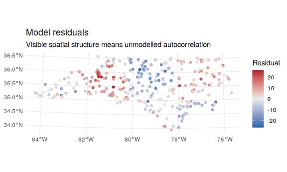

```r
plot(rf_fit, type = "residuals")
```

```r
mi <- residual_morans_i(rf_fit)
cat(sprintf("Moran's I = %.4f (z = %.2f, p = %.3g)\n",
            mi$observed, mi$z, mi$p_value))
```

```
## Moran's I = 0.5443 (z = 20.12, p = 4.58e-90)
```

### GWR, if `GWmodel` is installed

```r
gwr_fit <- fit_gwr_model(
  data_sf        = points_sf,
  response_var   = "y",
  predictor_vars = c("elevation", "pop_density"),
  adaptive       = TRUE,
  kernel         = "bisquare"
)

gwr_met <- model_metrics(gwr_fit)
cat(sprintf("Bandwidth: %.1f | in-sample R2: %.3f | RMSE: %.3f\n",
            gwr_fit$info$bandwidth, gwr_met$R2, gwr_met$RMSE))
```

### Comparing backends on identical folds

`compare_models_cv()` cross-validates each requested backend on the `folds` you pass. Any backend whose package is missing is dropped with a message, so the call still returns whatever could run.

```r
cmp <- compare_models_cv(
  points_sf, "y", c("elevation", "pop_density"),
  models   = c("RF", "GWR"),
  folds    = folds_blocked,
  rf_args  = list(num_trees = 300)
)
cmp$overall
```

```
##       RMSE      MAE     MAPE    SMAPE        R2 Adj_R2 n_pred model
## 1 12.37304 10.21057 11.26284 11.15191 0.3023388     NA    300    RF
```

## 7. From a fit to a map, and where the map applies

`predict_surface()` builds a regular grid over the training extent, joins covariates from the nearest observation, clips to the boundary and predicts:

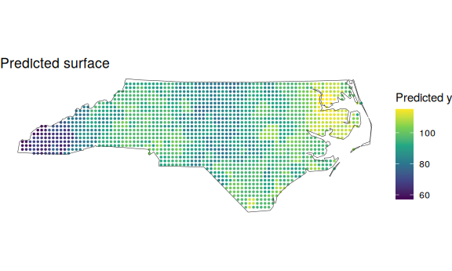

```r
surf <- predict_surface(rf_fit, n_cells = 3000,
                        covariates = points_sf, boundary = nc_boundary)

ggplot() +
  geom_sf(data = surf, aes(colour = .pred), size = 0.6) +
  geom_sf(data = nc_boundary, fill = NA, colour = "grey20") +
  scale_colour_viridis_c(name = "Predicted y") +
  theme_void() +
  ggtitle("Predicted surface")
```

A fitted model returns a number for any location you hand it, including locations whose predictor values look nothing like the training data. `area_of_applicability()` marks where the cross-validated score actually applies. Pass the folds you validated with:

```r
aoa <- area_of_applicability(surf, model = rf_fit, folds = folds_blocked)

cat(sprintf("inside: %d | outside: %d | undetermined: %d | DI threshold %.3f\n",
            aoa$n_inside, aoa$n_outside, aoa$n_na, aoa$threshold))
```

```
## inside: 1629 | outside: 0 | undetermined: 0 | DI threshold 0.184
```

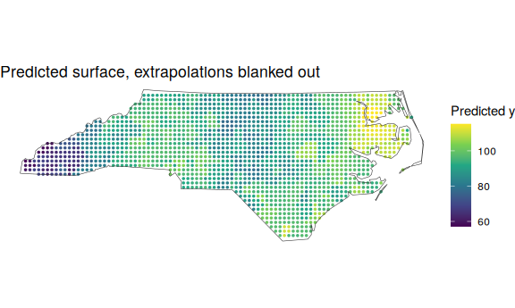

```r
# AOA is NA wherever a predictor was missing or non-finite, and `!NA` is NA,
# which R silently skips in a subscripted assignment. Test for TRUE and let
# anything else count as outside.
inside <- aoa$aoa$AOA %in% TRUE
surf$.pred_masked <- ifelse(inside, surf$.pred, NA_real_)

ggplot() +
  geom_sf(data = surf, aes(colour = .pred_masked), size = 0.6) +
  geom_sf(data = nc_boundary, fill = NA, colour = "grey20") +
  scale_colour_viridis_c(name = "Predicted y", na.value = "grey85") +
  theme_void() +
  ggtitle("Predicted surface, extrapolations blanked out")
```

Nothing is masked here, and the reason is worth understanding rather than taking as reassurance: `predict_surface(covariates = points_sf)` copies predictor values from the **nearest observation**, so every grid cell carries a predictor vector some training point already had. Its dissimilarity index is therefore near zero by construction. The index earns its keep when the covariates come from somewhere else — a raster, a different survey, a future scenario. Hand it values outside the training range and it says so:

```r
extreme <- st_sf(
  elevation   = c(mean(points_sf$elevation), max(points_sf$elevation) * 4),
  pop_density = c(mean(points_sf$pop_density), max(points_sf$pop_density) * 4),
  geometry    = st_geometry(points_sf)[1:2]
)
area_of_applicability(extreme, model = rf_fit, folds = folds_blocked)$aoa[, c("DI", "AOA")]
```

```
## Simple feature collection with 2 features and 2 fields
## Geometry type: POINT
## Dimension:     XY
## Bounding box:  xmin: 2604137 ymin: 653637.4 xmax: 2827401 ymax: 964007.8
## Projected CRS: NAD83 / North Carolina (ftUS)
##            DI   AOA                 geometry
## 1  0.04321651  TRUE POINT (2827401 653637.4)
## 2 15.00736636 FALSE POINT (2604137 964007.8)
```

## Summary

| Tessellation | Cells | Notes |
| --- | --- | --- |
| Voronoi | 40 | Adapts to point density via k-means seeds |
| Hex grid | 49 | Uniform hexagons, good for regular sampling |
| Square grid | 45 | Simplest regular grid |
| Delaunay | 586 | One triangle per Delaunay triplet; finest resolution |

The choropleths show how each tessellation aggregates the response. Section 5 shows the thing that matters most: on the same data and the same fitted model, the fold scheme moves the reported score substantially, and only the blocked number describes the task you actually have.